# 2025 Paleontological Society Short Course

Open Science, Collaboration, and Reproducibility in Paleontology

[figure not shown]

## Organizer Introductions

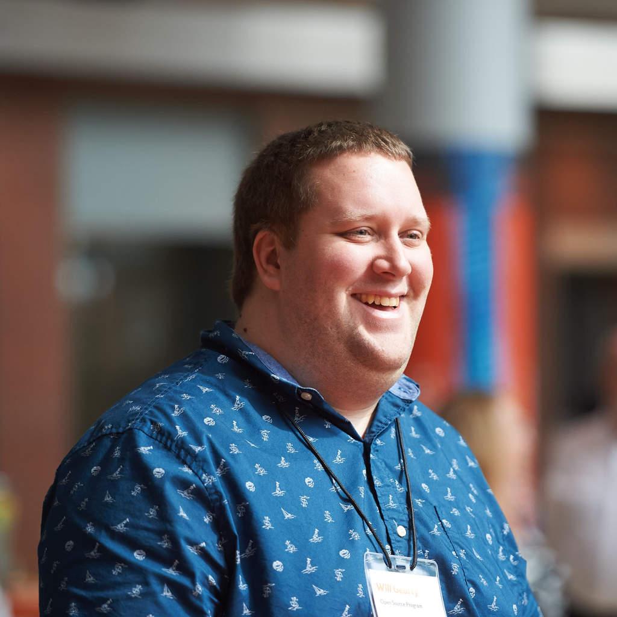

Will Gearty

Syracuse University

[figure not shown]

Erin Dillon

Smithsonian Tropical Research Institute

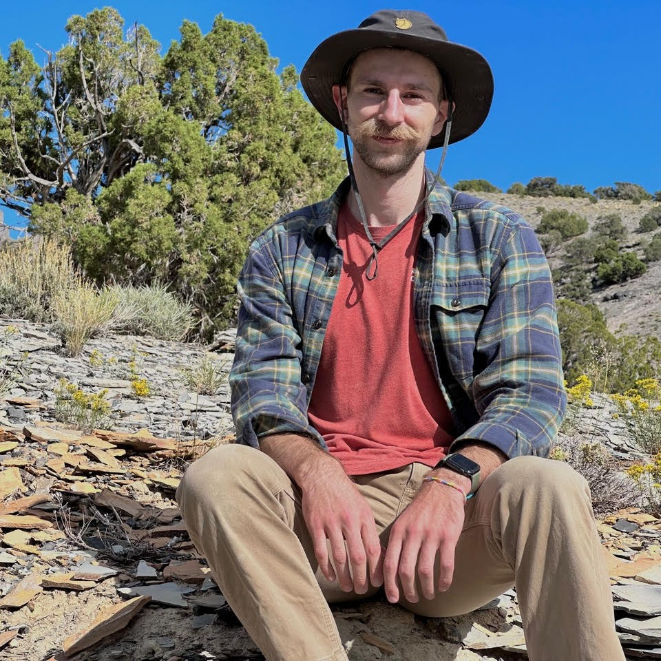

Mark Nikolic

Stanford University

## Palaeoverse

[figure not shown]

## Guest Introductions

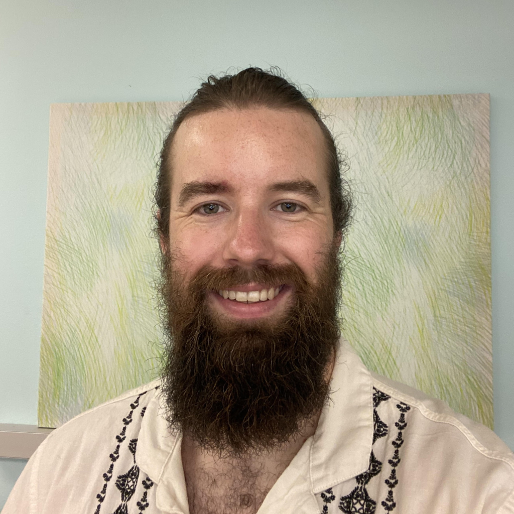

Broc Kokesh

University of California, Berkeley

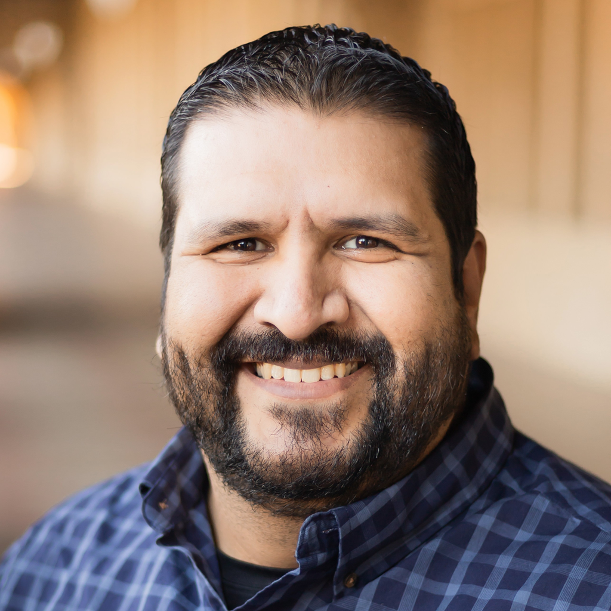

Pedro M. Monarrez

Virginia Tech

## Why open science?

- Open science aims to make research and its outcomes—at all stages—more accessible
  - Increases transparency, reproducibility, and reusability
  - Facilitates collaboration
  - Broadens access to scientific knowledge
  - Enhance the impact and reach of our science

## Objectives

- **Goal:** overview of how to process paleontological data in an open and reproducible way
- **Learning objectives:**
  - Gain exposure to tools and best practices for developing and sharing reproducible workflows
  - Build confidence working with data in R
  - Practice coding collaboratively
  - Connect with other workshop participants

## Resources

- **You’ll walk away with:**
  - Template for creating a workflow and example code that you can adapt to your own work
  - Workshop materials and resources
  - An expanded network of colleagues
- **Workshop website:** https://workshop.palaeoverse.org

## Schedule

| Time | Event |
| --- | --- |
| **08:00 AM** | **Welcome and introduction** |
| **08:30 AM** | **Setting up a reproducible workflow (GitHub, GitHub Desktop, RStudio)** |
| **10:00 AM** | *Coffee break* ☕ |
| **10:15 AM** | **Data acquisition** |
| **10:45 AM** | **Data Processing I: Data exploration and cleaning** |
| **12:00 PM** | *Lunch break* 🥪 |
| **1:30 PM** | **Data Processing II: Data visualization and synthesis** |
| **3:15 PM** | *Coffee break* ☕ |
| **3:30 PM** | **Ethical open science** |
| **4:45 PM** | **Closing remarks** |

## Logistics

- Room 211
- Restrooms
- Exits
- Internet

## Raise your hand if…

- you are just getting started in R
- you feel comfortable coding in R
- you work with R so much that you dream in ggplot
- you have used GitHub before
- you have downloaded data from a database
- you have archived your data and/or code

## Meet your colleagues!

- Name
- Institution
- Career stage
- Research interests
- Example of open science in action?